# Assignment_5

2022-11-20

##Inputting and Setting up Data/Packages

```r
mydata <- read.csv("C:\\Users\\bucol\\Downloads\\Cereals.csv")
library(tidyverse)  # data manipulation
library(factoextra) # clustering algorithms & visualization
library(cluster)
library(caret)
set.seed(49)


summary(mydata)
```

```
##      name               mfr                type              calories
##  Length:77          Length:77          Length:77          Min.   : 50.0
##  Class :character   Class :character   Class :character   1st Qu.:100.0
##  Mode  :character   Mode  :character   Mode  :character   Median :110.0
##                                                           Mean   :106.9
##                                                           3rd Qu.:110.0
##                                                           Max.   :160.0
##
##     protein           fat            sodium          fiber
##  Min.   :1.000   Min.   :0.000   Min.   :  0.0   Min.   : 0.000
##  1st Qu.:2.000   1st Qu.:0.000   1st Qu.:130.0   1st Qu.: 1.000
##  Median :3.000   Median :1.000   Median :180.0   Median : 2.000
##  Mean   :2.545   Mean   :1.013   Mean   :159.7   Mean   : 2.152
##  3rd Qu.:3.000   3rd Qu.:2.000   3rd Qu.:210.0   3rd Qu.: 3.000
##  Max.   :6.000   Max.   :5.000   Max.   :320.0   Max.   :14.000
##
##      carbo          sugars           potass          vitamins
##  Min.   : 5.0   Min.   : 0.000   Min.   : 15.00   Min.   :  0.00
##  1st Qu.:12.0   1st Qu.: 3.000   1st Qu.: 42.50   1st Qu.: 25.00
##  Median :14.5   Median : 7.000   Median : 90.00   Median : 25.00
##  Mean   :14.8   Mean   : 7.026   Mean   : 98.67   Mean   : 28.25
##  3rd Qu.:17.0   3rd Qu.:11.000   3rd Qu.:120.00   3rd Qu.: 25.00
##  Max.   :23.0   Max.   :15.000   Max.   :330.00   Max.   :100.00
##  NA's   :1      NA's   :1        NA's   :2
##      shelf           weight          cups           rating
##  Min.   :1.000   Min.   :0.50   Min.   :0.250   Min.   :18.04
##  1st Qu.:1.000   1st Qu.:1.00   1st Qu.:0.670   1st Qu.:33.17
##  Median :2.000   Median :1.00   Median :0.750   Median :40.40
##  Mean   :2.208   Mean   :1.03   Mean   :0.821   Mean   :42.67
##  3rd Qu.:3.000   3rd Qu.:1.00   3rd Qu.:1.000   3rd Qu.:50.83
##  Max.   :3.000   Max.   :1.50   Max.   :1.500   Max.   :93.70
##
```

#We see there is some missing data that needs to be removed

```r
cerealscomplete <- na.omit(mydata)
cerealscomplete #this has removed the cereals with incomplete data
```

```
##                                      name mfr type calories protein fat sodium
## 1                               100%_Bran   N    C       70       4   1    130
## 2                       100%_Natural_Bran   Q    C      120       3   5     15
## 3                                All-Bran   K    C       70       4   1    260
## 4               All-Bran_with_Extra_Fiber   K    C       50       4   0    140
## 6                 Apple_Cinnamon_Cheerios   G    C      110       2   2    180
## 7                             Apple_Jacks   K    C      110       2   0    125
## 8                                 Basic_4   G    C      130       3   2    210
## 9                               Bran_Chex   R    C       90       2   1    200
## 10                            Bran_Flakes   P    C       90       3   0    210
## 11                           Cap'n'Crunch   Q    C      120       1   2    220
## 12                               Cheerios   G    C      110       6   2    290
## 13                  Cinnamon_Toast_Crunch   G    C      120       1   3    210
## 14                               Clusters   G    C      110       3   2    140
## 15                            Cocoa_Puffs   G    C      110       1   1    180
```

[output cut: 135 more lines]

```r
#Now we need to make the cereal names the row names
row.names(cerealscomplete) <- cerealscomplete[,1]
#now we must remove the names from the dataset
cerealscomplete <- cerealscomplete[,-1]

#I'm going to remove the first two columns because they're categorical.
cerealscomplete <- cerealscomplete[,-1]
cerealscomplete <- cerealscomplete[,-1]
cerealscomplete
```

```
##                                        calories protein fat sodium fiber carbo
## 100%_Bran                                    70       4   1    130  10.0   5.0
## 100%_Natural_Bran                           120       3   5     15   2.0   8.0
## All-Bran                                     70       4   1    260   9.0   7.0
## All-Bran_with_Extra_Fiber                    50       4   0    140  14.0   8.0
## Apple_Cinnamon_Cheerios                     110       2   2    180   1.5  10.5
## Apple_Jacks                                 110       2   0    125   1.0  11.0
## Basic_4                                     130       3   2    210   2.0  18.0
## Bran_Chex                                    90       2   1    200   4.0  15.0
## Bran_Flakes                                  90       3   0    210   5.0  13.0
## Cap'n'Crunch                                120       1   2    220   0.0  12.0
## Cheerios                                    110       6   2    290   2.0  17.0
## Cinnamon_Toast_Crunch                       120       1   3    210   0.0  13.0
## Clusters                                    110       3   2    140   2.0  13.0
## Cocoa_Puffs                                 110       1   1    180   0.0  12.0
## Corn_Chex                                   110       2   0    280   0.0  22.0
## Corn_Flakes                                 100       2   0    290   1.0  21.0
## Corn_Pops                                   110       1   0     90   1.0  13.0
## Count_Chocula                               110       1   1    180   0.0  12.0
## Cracklin'_Oat_Bran                          110       3   3    140   4.0  10.0
## Crispix                                     110       2   0    220   1.0  21.0
## Crispy_Wheat_&_Raisins                      100       2   1    140   2.0  11.0
## Double_Chex                                 100       2   0    190   1.0  18.0
## Froot_Loops                                 110       2   1    125   1.0  11.0
## Frosted_Flakes                              110       1   0    200   1.0  14.0
## Frosted_Mini-Wheats                         100       3   0      0   3.0  14.0
## Fruit_&_Fibre_Dates,_Walnuts,_and_Oats      120       3   2    160   5.0  12.0
## Fruitful_Bran                               120       3   0    240   5.0  14.0
## Fruity_Pebbles                              110       1   1    135   0.0  13.0
## Golden_Crisp                                100       2   0     45   0.0  11.0
## Golden_Grahams                              110       1   1    280   0.0  15.0
## Grape_Nuts_Flakes                           100       3   1    140   3.0  15.0
## Grape-Nuts                                  110       3   0    170   3.0  17.0
## Great_Grains_Pecan                          120       3   3     75   3.0  13.0
## Honey_Graham_Ohs                            120       1   2    220   1.0  12.0
## Honey_Nut_Cheerios                          110       3   1    250   1.5  11.5
## Honey-comb                                  110       1   0    180   0.0  14.0
## Just_Right_Crunchy__Nuggets                 110       2   1    170   1.0  17.0
## Just_Right_Fruit_&_Nut                      140       3   1    170   2.0  20.0
## Kix                                         110       2   1    260   0.0  21.0
```

[output cut: 170 more lines]

```
## Rice_Krispies                          40.56016
## Shredded_Wheat                         68.23588
## Shredded_Wheat_'n'Bran                 74.47295
## Shredded_Wheat_spoon_size              72.80179
## Smacks                                 31.23005
## Special_K                              53.13132
## Strawberry_Fruit_Wheats                59.36399
## Total_Corn_Flakes                      38.83975
## Total_Raisin_Bran                      28.59278
## Total_Whole_Grain                      46.65884
## Triples                                39.10617
## Trix                                   27.75330
## Wheat_Chex                             49.78744
## Wheaties                               51.59219
## Wheaties_Honey_Gold                    36.18756
```

#Since we are dealing with very different variables, we must normalize the data

```r
normcereal <- scale(cerealscomplete)
summary(normcereal) #now our data is scaled.
```

```
##     calories          protein              fat              sodium
##  Min.   :-2.8738   Min.   :-1.40687   Min.   :-0.9932   Min.   :-1.9616
##  1st Qu.:-0.3541   1st Qu.:-0.47733   1st Qu.:-0.9932   1st Qu.:-0.3306
##  Median : 0.1498   Median :-0.01256   Median : 0.0000   Median : 0.2131
##  Mean   : 0.0000   Mean   : 0.00000   Mean   : 0.0000   Mean   : 0.0000
##  3rd Qu.: 0.1498   3rd Qu.: 0.45221   3rd Qu.: 0.0000   3rd Qu.: 0.6661
##  Max.   : 2.6695   Max.   : 3.24083   Max.   : 3.9729   Max.   : 1.9045
##      fiber              carbo              sugars            potass
##  Min.   :-0.89778   Min.   :-2.50014   Min.   :-1.6306   Min.   :-1.1783
##  1st Qu.:-0.79462   1st Qu.:-0.70143   1st Qu.:-0.9424   1st Qu.:-0.8079
##  Median :-0.07249   Median :-0.05903   Median :-0.0248   Median :-0.1201
##  Mean   : 0.00000   Mean   : 0.00000   Mean   : 0.0000   Mean   : 0.0000
##  3rd Qu.: 0.34015   3rd Qu.: 0.58337   3rd Qu.: 0.8928   3rd Qu.: 0.3031
##  Max.   : 4.87925   Max.   : 2.12512   Max.   : 1.8104   Max.   : 3.2660
##     vitamins           shelf             weight             cups
##  Min.   :-1.3032   Min.   :-1.4617   Min.   :-3.4600   Min.   :-2.4251
##  1st Qu.:-0.1818   1st Qu.:-1.1612   1st Qu.:-0.2008   1st Qu.:-0.6432
##  Median :-0.1818   Median :-0.2599   Median :-0.2008   Median :-0.3038
##  Mean   : 0.0000   Mean   : 0.0000   Mean   : 0.0000   Mean   : 0.0000
##  3rd Qu.:-0.1818   3rd Qu.: 0.9420   3rd Qu.:-0.2008   3rd Qu.: 0.7568
##  Max.   : 3.1822   Max.   : 0.9420   Max.   : 3.0583   Max.   : 2.8780
##      rating
##  Min.   :-1.7336
##  1st Qu.:-0.7071
##  Median :-0.1510
##  Mean   : 0.0000
##  3rd Qu.: 0.5807
##  Max.   : 3.6578
```

#Now we will use Agnes to compare single, complete, and average linkage and Ward.

```r
set.seed(17)
hc_single <- agnes(normcereal, method = "single")
hc_complete <- agnes(normcereal, method = "complete")
hc_average <- agnes(normcereal, method = "average")
hc_ward <- agnes(normcereal, method = "ward")

#The we compare agglomerative coefficients
print(hc_single$ac) #0.6067859
```

```
## [1] 0.6067859
```

```r
print(hc_complete$ac) #0.8353712
```

```
## [1] 0.8353712
```

```r
print(hc_average$ac) #0.7766075
```

```
## [1] 0.7766075
```

```r
print(hc_ward$ac) #0.9046042  (this one is the highest)
```

```
## [1] 0.9046042
```

#Based on the agglomerative coefficients, the ward method is the best. #we will now plot the dendrogram

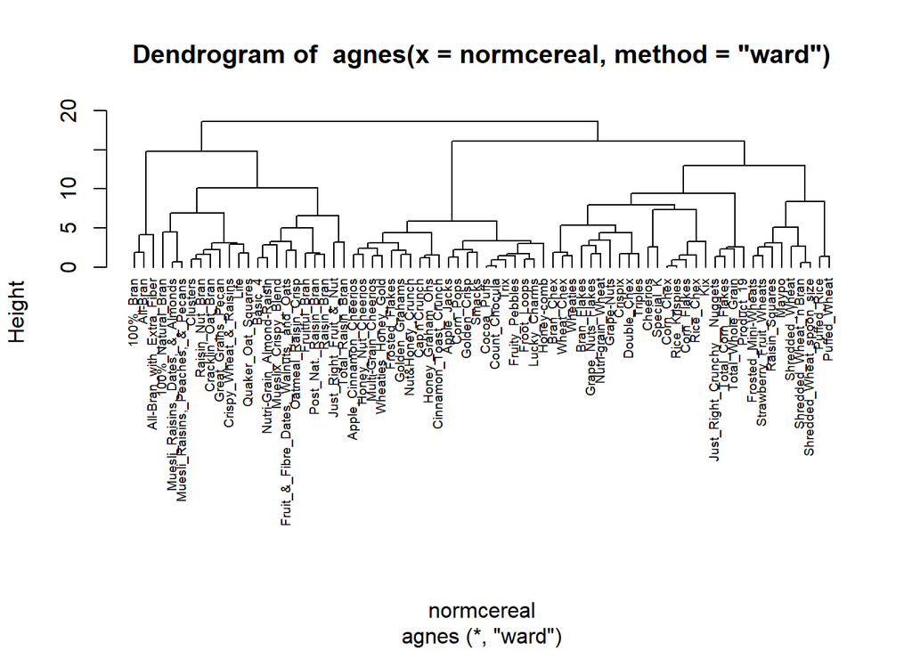

```r
plot_ward <- pltree(hc_ward, cex = 0.6, hang = -1)
```

```r
plot_ward
```

#Looking at the dendrogram, I think 6 clusters seems pretty good.

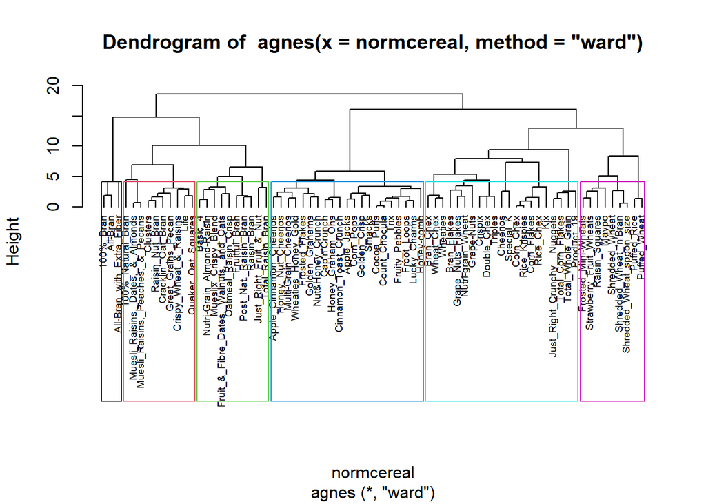

```r
pltree(hc_ward, cex = 0.6, hang = -1)
rect.hclust(hc_ward,k=6,border = 1:6)
```

#Now we check their stability. #First, we partition.

```r
set.seed(17)

#Creating partition set of 50%
partset <- createDataPartition(normcereal[,"calories"], p=0.5, list = FALSE)
CerA <- normcereal[partset,] #this is the first 50%
CerB <- normcereal[-partset,]#second set

#Now we'll run the AGNES to both sets.
a_ward <-agnes(CerA, method = "ward")
print(a_ward$ac) #0.8498682
```

```
## [1] 0.8498682
```

```r
b_ward <-agnes(CerB, method = "ward")
print(b_ward$ac) #0.8383771
```

```
## [1] 0.8383771
```

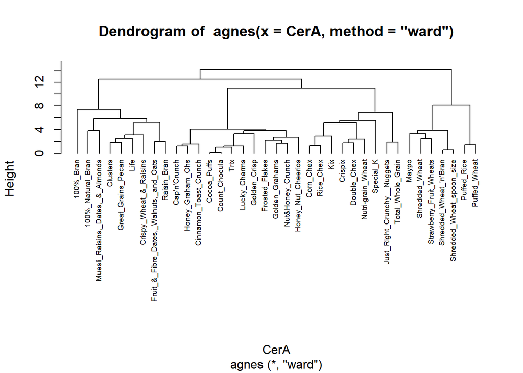

```r
#we can note that the agglomerative coefficients are very similar.

plot_a <- pltree(a_ward, cex=0.6, hang = -1)
```

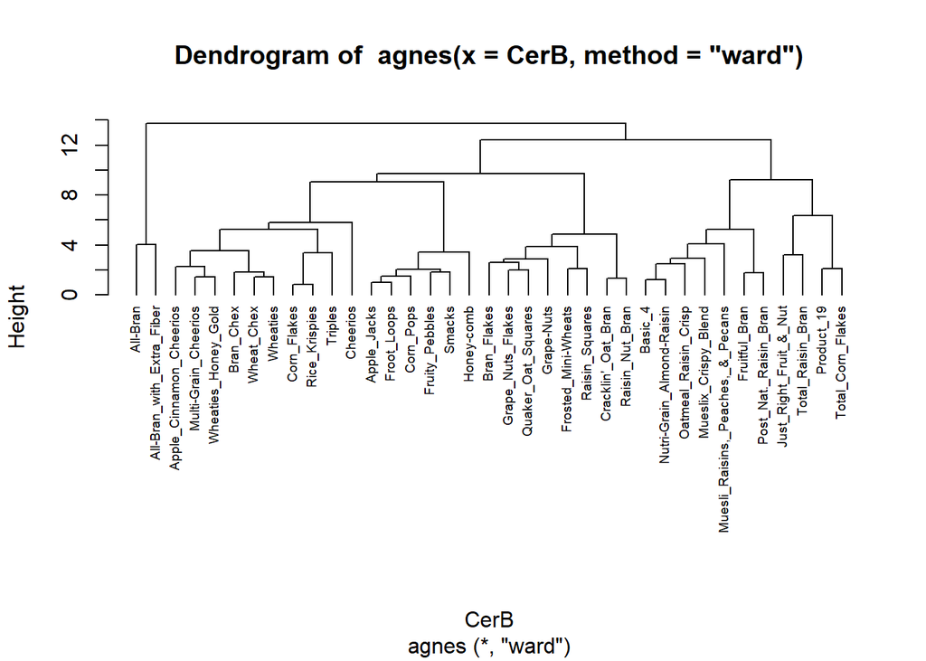

```r
plot_b <- pltree(b_ward, cex=0.6, hang = -1)
```

If I compare these partitioned dendrograms to the original, we can see that most cereals remain in the same cluster. This tells us that it is pretty stable.

#Senario: Find cluster of healthy cereal. Okay, since we want healthy cereals we should be considering the nutrional items in this data set and their importance. We probably are looking at some that should be high and some that would be better low. high: protein, fiber, potassium, vitamins, and honestly rating since we want the kids to actually eat it.  
low: fat, sodium now calories and carbs are also important, but I dont think we specifically want them high or low since it needs to be balanced between healthy and filling. For the purpose of this analysis, I would to fet rid of shelf.  
To be honest, looking at this data, its a bit unbalanced because of the serving sizes which I assume is what cups is. If we really wanted to consider these on an equal playing field, we should probably make a ratio of the nutritional aspect per its cups so that all the nutritional data is scaled similarly. ie, a cereal doesn’t look healthier because its just less food. Also, due to the importance of scale here, you would want to manipulate your data depending on health benefit importance, so normalizing the data would not be the first option since we do care about the actual values of the nutritional facts.